# RHC

## Propensity score matching for the evaluation of relative treatment efficacies.

In this dataset, the treatments of patients in the ICU is recorded. Some of these patients recieved a treatment called Right-Heart-Catheterization (RHC). If we are interested in finding out if RHC changes a patient's chances of survival, we need to compare those patients that recieved RHC with those patients that did not.

Imagine if 100 pairs of identical twins were admitted to the ICU, with both members of each pair suffering from identical illnesses. It would then be very easy to find out if RHC was helpful, by giving RHC to only one member of each pair, and seeing if more of the RHC-treated twins survived.

However, this dataset wasn't built that way (and this would probably be unethical). Instead, the patients are considered individually, and the likelihood of a patient receiving RHC might have been dependent on how sick their doctor thought they were and the specifics of their individual cases. This means that patients recieving RHC might have been more or less likely to die regardless of whether they recieved RHC, which makes direct comparison of the treated/untreated patients meaningless.

However, there is a way to make useful comparisons from the dataset. We have quite a lot of information about each patient, and we can use this information to find, for each patient that recieved RHC, a very similar patient that did not recieve RHC. We can think of this as finding an "adopted twin" for the patient. By comparing these paired treated and untreated patients we can now make a meaningful evaluation of the effectiveness of the treatment. This approach is called propensity score matching, meaning that we match control and experimental cases based on their having similar propensities for recieving the treatment.

One weakness of this approach is that it relies on knowing all of the variables that might make a difference to whether a patient was given the treatment or not. In this example, doctors may be using knowledge and experience not captured in the patient data to make their treatment decisions. We can assess this to some extent by evaluating how accurately the model predicts treatment group assignnment. Another weakness stems from the assumption that good matching pairs exist within the sample. If the two groups are sufficiently different, then this technique will not work. This means that this approach is most suitable when the best choice governing treatment assignment is ambiguous.

This technique can be applied to a number of areas beyond medicine, for example in comparing the effectiveness of different internet advertisements on click-through rates.

```python
import pandas
import numpy as np
import matplotlib.pyplot as plt
import seaborn as sns
from sklearn.linear_model import LogisticRegression
from sklearn.linear_model import BayesianRidge
from sklearn.metrics import roc_auc_score, auc,roc_curve
%matplotlib inline
```

```python
rhc = pandas.read_csv("rhc.csv")
```

```python
rhc.head()
```

|  | Unnamed: 0 | cat1 | cat2 | ca | sadmdte | dschdte | dthdte | lstctdte | death | cardiohx | ... | meta | hema | seps | trauma | ortho | adld3p | urin1 | race | income | ptid |
| --- | --- | --- | --- | --- | --- | --- | --- | --- | --- | --- | --- | --- | --- | --- | --- | --- | --- | --- | --- | --- | --- |
| 0 | 1 | COPD | NaN | Yes | 11142 | 11151 | NaN | 11382 | No | 0 | ... | No | No | No | No | No | 0 | NaN | white | Under $11k | 5 |
| 1 | 2 | MOSF w/Sepsis | NaN | No | 11799 | 11844 | 11844 | 11844 | Yes | 1 | ... | No | No | Yes | No | No | NaN | 1437 | white | Under $11k | 7 |
| 2 | 3 | MOSF w/Malignancy | MOSF w/Sepsis | Yes | 12083 | 12143 | NaN | 12400 | No | 0 | ... | No | No | No | No | No | NaN | 599 | white | $25-$50k | 9 |
| 3 | 4 | ARF | NaN | No | 11146 | 11183 | 11183 | 11182 | Yes | 0 | ... | No | No | No | No | No | NaN | NaN | white | $11-$25k | 10 |
| 4 | 5 | MOSF w/Sepsis | NaN | No | 12035 | 12037 | 12037 | 12036 | Yes | 0 | ... | No | No | No | No | No | NaN | 64 | white | Under $11k | 11 |

5 rows × 63 columns

### Firstly, the data needs to be tidied up and converted into a format suitable for the analysis.

```python
rhc.swang1 = np.where(rhc.swang1=="RHC",1,0)
```

```python
for c in rhc.columns:
    if "Yes" in rhc[c].values:
        rhc[c] = np.where(rhc[c]=="Yes",1,0)
```

```python
def oneHot(dataframe):
    msk = dataframe.dtypes == object
    nominals = dataframe.loc[:,msk].columns
    nom_dfs = [pandas.get_dummies(dataframe[n]) for n in nominals]
    p=pandas.concat(nom_dfs,axis=1)
    dataframe.drop(nominals,axis=1,inplace=True)
    return pandas.concat([dataframe,p],axis=1)
```

```python
rhc = oneHot(rhc)
```

```python
from sklearn.preprocessing import Imputer
imp = Imputer(missing_values='NaN', strategy='mean', axis=0)
imputed = imp.fit_transform(rhc.values)
```

### The second step is to build a model to predict if a patient recieves RHC treatment, based on the other observed variables. The most common model type for this step is logistic regression, but I am also going to try Bayesian Ridge Regression.

```python
rhc = pandas.DataFrame(imputed,columns=rhc.columns)
```

```python
X = rhc.drop(["death","swang1"],axis=1).values
Y=rhc.swang1.values
```

```python
logit = LogisticRegression(C=1.0, penalty='l1', tol=1e-6)
logit.fit(X,Y)
```

```
LogisticRegression(C=1.0, class_weight=None, dual=False, fit_intercept=True,
          intercept_scaling=1, penalty='l1', random_state=None, tol=1e-06)
```

```python
brr = BayesianRidge()
brr.fit(X,Y)
```

```
BayesianRidge(alpha_1=1e-06, alpha_2=1e-06, compute_score=False, copy_X=True,
       fit_intercept=True, lambda_1=1e-06, lambda_2=1e-06, n_iter=300,
       normalize=False, tol=0.001, verbose=False)
```

```python
propensities = logit.predict_proba(X)
logit_predict = logit.predict(X)
bayesian_ridge = brr.predict(X)
```

```python
rhc["logit_propensities"] = propensities[:,1]
rhc["bayes_propensities"]=bayesian_ridge
rhc.head()
```

|  | Unnamed: 0 | ca | sadmdte | dschdte | dthdte | lstctdte | death | cardiohx | chfhx | dementhx | ... | Private & Medicare | black | other | white | $11-$25k | $25-$50k | > $50k | Under $11k | logit_propensities | bayes_propensities |
| --- | --- | --- | --- | --- | --- | --- | --- | --- | --- | --- | --- | --- | --- | --- | --- | --- | --- | --- | --- | --- | --- |
| 0 | 1 | 1 | 11142 | 11151 | 11753.869156 | 11382 | 0 | 0 | 0 | 0 | ... | 0 | 0 | 0 | 1 | 0 | 0 | 0 | 1 | 0.334628 | 0.383577 |
| 1 | 2 | 0 | 11799 | 11844 | 11844.000000 | 11844 | 1 | 1 | 1 | 0 | ... | 1 | 0 | 0 | 1 | 0 | 0 | 0 | 1 | 0.564612 | 0.590311 |
| 2 | 3 | 1 | 12083 | 12143 | 11753.869156 | 12400 | 0 | 0 | 0 | 0 | ... | 0 | 0 | 0 | 1 | 0 | 1 | 0 | 0 | 0.550065 | 0.572651 |
| 3 | 4 | 0 | 11146 | 11183 | 11183.000000 | 11182 | 1 | 0 | 0 | 0 | ... | 1 | 0 | 0 | 1 | 1 | 0 | 0 | 0 | 0.341432 | 0.354446 |
| 4 | 5 | 0 | 12035 | 12037 | 12037.000000 | 12036 | 1 | 0 | 0 | 0 | ... | 0 | 0 | 0 | 1 | 0 | 0 | 0 | 1 | 0.431838 | 0.464717 |

5 rows × 89 columns

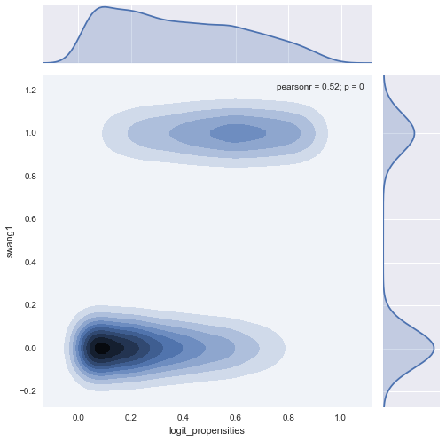

```python
sns.jointplot("logit_propensities", "swang1",data=rhc, kind="kde", size=7)
```

```python
roc_auc_score(Y, logit_predict, average='macro', sample_weight=None)
```

```
0.70704364864460612
```

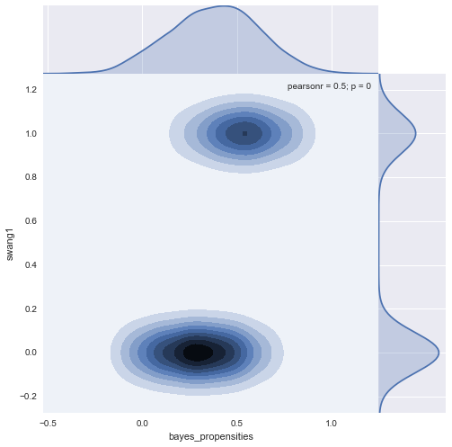

```python
sns.jointplot("bayes_propensities", "swang1",data=rhc, kind="kde", size=7, space=0)
```

```python
roc_auc_score(Y, bayesian_ridge, average='macro', sample_weight=None)
```

```
0.80408410466844715
```

```python
brr_fpr,brr_tpr, _ = roc_curve(Y, bayesian_ridge)
logit_fpr,logit_tpr,_ = roc_curve(Y,logit_predict)
```

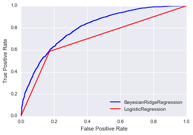

```python
plt.plot(brr_fpr,brr_tpr,color="blue",label="BayesianRidgeRegression")
plt.plot(logit_fpr,logit_tpr,color="red",label="LogisticRegression")
plt.xlabel('False Positive Rate')
plt.ylabel('True Positive Rate')
plt.legend(loc="lower right")
```

### It looks like the Bayesian Ridge Regression Model has a better ROC, but it is also crucial to minimize the differences in confounding variables between the paired partners. For this reason, the Mahalanobis Distance across all pairings might be a more useful evaluation method. This is a way of describing how similar two cases are, taking into consideration how much variation naturally occurs between the cases for each of their variables. So now we will use the BRR and LR models to match cases, and compare their performance based on the average Mahalanobis Distance between the pairs they generate.

```python
rhc['propensities']=propensities[:,1]
rhc['bayesprop'] = bayesian_ridge
```

```python
untreated_df = rhc[rhc.swang1==0].reset_index()
matchings=[]
differences=[]
def greedyMatcher(treated_row,untreated_df=untreated_df,matchings=matchings):
    delta_p = np.abs(untreated_df.bayesprop - treated_row.bayesprop)
    partner_index = np.argmin(delta_p)
    partner = untreated_df.loc[partner_index]
    matchings.append((treated_row.death,partner.death,delta_p[partner_index],partner["Unnamed: 0"]))
    differences.append((treated_row - partner).values)
    untreated_df.drop(partner_index,inplace=True)
```

```python
treated = rhc[rhc.swang1==1].reset_index()
```

```python
treated.apply(greedyMatcher,axis=1)
```

```
0       None
1       None
2       None
3       None
4       None
5       None
6       None
7       None
8       None
9       None
10      None
11      None
12      None
13      None
14      None
```

[output cut: 47 more lines]

```python
bayes_matchings = matchings
```

```python
std_dv = rhc.std(axis=0)
differences_df = (pandas.DataFrame(np.array(differences),columns=treated.columns).drop("index",axis=1))
zdifferences_df = (pandas.DataFrame(np.array(differences),columns=treated.columns).drop("index",axis=1))/std_dv
```

```python
bayes_rr_total_mismatch = zdifferences_df.sum().sum()
```

```python
bayes_mahalanobis = zdifferences_df.apply(lambda x : np.sqrt((x.map(lambda y: y**2)).sum()) ,axis=1)
```

```python
np.mean(bayes_mahalanobis)
```

```
12.84069183344517
```

```python
untreated_df = rhc[rhc.swang1==0].reset_index()
matchings=[]
differences=[]
def greedyMatcher(treated_row,untreated_df=untreated_df,matchings=matchings):
    delta_p = np.abs(untreated_df.propensities - treated_row.propensities)
    partner_index = np.argmin(delta_p)
    partner = untreated_df.loc[partner_index]
    matchings.append((treated_row.death,partner.death,delta_p[partner_index],partner["Unnamed: 0"]))
    differences.append((treated_row - partner).values)
    untreated_df.drop(partner_index,inplace=True)
```

```python
treated = rhc[rhc.swang1==1].reset_index()
treated.apply(greedyMatcher,axis=1)
```

```
0     None
1     None
2     None
3     None
4     None
5     None
6     None
7     None
8     None
9     None
10    None
11    None
12    None
13    None
14    None
```

[output cut: 17 more lines]

```python
std_dv = rhc.std(axis=0)
differences_df = (pandas.DataFrame(np.array(differences),columns=treated.columns).drop("index",axis=1))
logit_zdifferences_df = (pandas.DataFrame(np.array(differences),columns=treated.columns).drop("index",axis=1))/std_dv
```

```python
logit_total_mismatch = logit_zdifferences_df.sum().sum()
```

```python
logit_mahalanobis = logit_zdifferences_df.apply(lambda x : np.sqrt((x.map(lambda y: y**2)).sum()) ,axis=1)
```

```python
logit_total_mismatch,bayes_rr_total_mismatch
```

```
(5471.3492512385146, 5170.1015348706787)
```

```python
np.mean(logit_mahalanobis),np.mean(bayes_mahalanobis)
```

```
(12.799443242725493, 12.84069183344517)
```

### While there is little difference in the overall matching performance, with the total mismatch being slightly lower for the Bayesian Ridge Regression model, the Logistic Regression based approach has a slightly better Mahalanobis score. There is not much difference between the two methods, but the Bayesian Ridge Regression model is probably the better choice.

### Having now chosen a matching scheme, we can use the matched pairs to calculate the odds ratio between the RHC-treated and untreated cohorts.

```python
treated_deaths = sum([x[0] for x in bayes_matchings])
untreated_deaths = sum([x[1] for x in bayes_matchings])
treated_survivors = 2184-treated_deaths
untreated_survivors = 2184-untreated_deaths
```

```python
contingency = pandas.DataFrame(np.array([[treated_deaths,untreated_deaths],[treated_survivors,untreated_survivors]]),columns=["Treated","Untreated"],index=["Deaths","Survivals"])
```

```python
contingency = contingency.T
contingency
```

|  | Deaths | Survivals |
| --- | --- | --- |
| Treated | 1486 | 698 |
| Untreated | 1409 | 775 |

```python
odds = contingency/2184
odds
```

|  | Deaths | Survivals |
| --- | --- | --- |
| Treated | 0.680403 | 0.319597 |
| Untreated | 0.645147 | 0.354853 |

```python
log_odds_ratio = np.log((treated_deaths*treated_survivors)/(untreated_deaths*untreated_survivors))
log_odds_ratio
```

```
-0.05143621321195032
```

```python
log_odds_se = np.sqrt((1/treated_deaths + 1/treated_survivors+ 1/untreated_deaths + 1/untreated_survivors))
```

```python
lower_log_ci = log_odds_ratio - 1.96*log_odds_se
upper_log_ci = log_odds_ratio + 1.96*log_odds_se
```

```python
np.exp(lower_log_ci),np.exp(log_odds_ratio),np.exp(upper_log_ci)
```

```
(0.83775966539415103, 0.94986423681860843, 1.0769700495935293)
```